# Project: Investigate TMDb movie dataset

- Introduction
- Data Wrangling
- Exploratory Data Analysis
- Conclusions

## Introduction

> In the following we explore a dataset of movies from 1960 to 2015. We are going to investigate the popularity of different genres throught the whole period. We could find out which were the most popular movies and which were the less popular. Here we also address what factors influece the revenue of a movie.

```python
#Import libraries and packages
import pandas as pd
import numpy as np
import matplotlib.pyplot as plt
import mplcursors
%matplotlib inline
```

## Data Wrangling

> In this section we load and clean the data

### General Properties

```python
#We want to all our rows and columns so we use max_rows and max_columns
pd.options.display.max_rows = 200
pd.options.display.max_columns = 50
df = pd.read_csv('tmdb-movies.csv')
```

```python
#We explore the data using head
df.head(5)
```

|  | id | imdb_id | popularity | budget | revenue | original_title | cast | homepage | director | tagline | keywords | overview | runtime | genres | production_companies | release_date | vote_count | vote_average | release_year | budget_adj | revenue_adj |
| --- | --- | --- | --- | --- | --- | --- | --- | --- | --- | --- | --- | --- | --- | --- | --- | --- | --- | --- | --- | --- | --- |
| 0 | 135397 | tt0369610 | 32.985763 | 150000000 | 1513528810 | Jurassic World | Chris Pratt\|Bryce Dallas Howard\|Irrfan Khan\|Vi... | http://www.jurassicworld.com/ | Colin Trevorrow | The park is open. | monster\|dna\|tyrannosaurus rex\|velociraptor\|island | Twenty-two years after the events of Jurassic ... | 124 | Action\|Adventure\|Science Fiction\|Thriller | Universal Studios\|Amblin Entertainment\|Legenda... | 6/9/15 | 5562 | 6.5 | 2015 | 1.379999e+08 | 1.392446e+09 |
| 1 | 76341 | tt1392190 | 28.419936 | 150000000 | 378436354 | Mad Max: Fury Road | Tom Hardy\|Charlize Theron\|Hugh Keays-Byrne\|Nic... | http://www.madmaxmovie.com/ | George Miller | What a Lovely Day. | future\|chase\|post-apocalyptic\|dystopia\|australia | An apocalyptic story set in the furthest reach... | 120 | Action\|Adventure\|Science Fiction\|Thriller | Village Roadshow Pictures\|Kennedy Miller Produ... | 5/13/15 | 6185 | 7.1 | 2015 | 1.379999e+08 | 3.481613e+08 |
| 2 | 262500 | tt2908446 | 13.112507 | 110000000 | 295238201 | Insurgent | Shailene Woodley\|Theo James\|Kate Winslet\|Ansel... | http://www.thedivergentseries.movie/#insurgent | Robert Schwentke | One Choice Can Destroy You | based on novel\|revolution\|dystopia\|sequel\|dyst... | Beatrice Prior must confront her inner demons ... | 119 | Adventure\|Science Fiction\|Thriller | Summit Entertainment\|Mandeville Films\|Red Wago... | 3/18/15 | 2480 | 6.3 | 2015 | 1.012000e+08 | 2.716190e+08 |
| 3 | 140607 | tt2488496 | 11.173104 | 200000000 | 2068178225 | Star Wars: The Force Awakens | Harrison Ford\|Mark Hamill\|Carrie Fisher\|Adam D... | http://www.starwars.com/films/star-wars-episod... | J.J. Abrams | Every generation has a story. | android\|spaceship\|jedi\|space opera\|3d | Thirty years after defeating the Galactic Empi... | 136 | Action\|Adventure\|Science Fiction\|Fantasy | Lucasfilm\|Truenorth Productions\|Bad Robot | 12/15/15 | 5292 | 7.5 | 2015 | 1.839999e+08 | 1.902723e+09 |
| 4 | 168259 | tt2820852 | 9.335014 | 190000000 | 1506249360 | Furious 7 | Vin Diesel\|Paul Walker\|Jason Statham\|Michelle ... | http://www.furious7.com/ | James Wan | Vengeance Hits Home | car race\|speed\|revenge\|suspense\|car | Deckard Shaw seeks revenge against Dominic Tor... | 137 | Action\|Crime\|Thriller | Universal Pictures\|Original Film\|Media Rights ... | 4/1/15 | 2947 | 7.3 | 2015 | 1.747999e+08 | 1.385749e+09 |

```python
#We check how many rows and columns we have
df.shape
```

```
(10866, 21)
```

```python
#We check describe to have an idea about the mean, percentiles, min, max values
df.describe()
```

|  | id | popularity | budget | revenue | runtime | vote_count | vote_average | release_year | budget_adj | revenue_adj |
| --- | --- | --- | --- | --- | --- | --- | --- | --- | --- | --- |
| count | 10866.000000 | 10866.000000 | 1.086600e+04 | 1.086600e+04 | 10866.000000 | 10866.000000 | 10866.000000 | 10866.000000 | 1.086600e+04 | 1.086600e+04 |
| mean | 66064.177434 | 0.646441 | 1.462570e+07 | 3.982332e+07 | 102.070863 | 217.389748 | 5.974922 | 2001.322658 | 1.755104e+07 | 5.136436e+07 |
| std | 92130.136561 | 1.000185 | 3.091321e+07 | 1.170035e+08 | 31.381405 | 575.619058 | 0.935142 | 12.812941 | 3.430616e+07 | 1.446325e+08 |
| min | 5.000000 | 0.000065 | 0.000000e+00 | 0.000000e+00 | 0.000000 | 10.000000 | 1.500000 | 1960.000000 | 0.000000e+00 | 0.000000e+00 |
| 25% | 10596.250000 | 0.207583 | 0.000000e+00 | 0.000000e+00 | 90.000000 | 17.000000 | 5.400000 | 1995.000000 | 0.000000e+00 | 0.000000e+00 |
| 50% | 20669.000000 | 0.383856 | 0.000000e+00 | 0.000000e+00 | 99.000000 | 38.000000 | 6.000000 | 2006.000000 | 0.000000e+00 | 0.000000e+00 |
| 75% | 75610.000000 | 0.713817 | 1.500000e+07 | 2.400000e+07 | 111.000000 | 145.750000 | 6.600000 | 2011.000000 | 2.085325e+07 | 3.369710e+07 |
| max | 417859.000000 | 32.985763 | 4.250000e+08 | 2.781506e+09 | 900.000000 | 9767.000000 | 9.200000 | 2015.000000 | 4.250000e+08 | 2.827124e+09 |

```python
#With df.info we can see if there are missing values and the type of variables we have
#We can see some missing values but not in our columns of interest such as released_year, popularity, revenue_adj, etc
df.info()
```

```
<class 'pandas.core.frame.DataFrame'>
RangeIndex: 10866 entries, 0 to 10865
Data columns (total 21 columns):
 #   Column                Non-Null Count  Dtype
---  ------                --------------  -----
 0   id                    10866 non-null  int64
 1   imdb_id               10856 non-null  object
 2   popularity            10866 non-null  float64
 3   budget                10866 non-null  int64
 4   revenue               10866 non-null  int64
 5   original_title        10866 non-null  object
 6   cast                  10790 non-null  object
 7   homepage              2936 non-null   object
 8   director              10822 non-null  object
 9   tagline               8042 non-null   object
 10  keywords              9373 non-null   object
 11  overview              10862 non-null  object
 12  runtime               10866 non-null  int64
 13  genres                10843 non-null  object
 14  production_companies  9836 non-null   object
 15  release_date          10866 non-null  object
 16  vote_count            10866 non-null  int64
 17  vote_average          10866 non-null  float64
 18  release_year          10866 non-null  int64
 19  budget_adj            10866 non-null  float64
 20  revenue_adj           10866 non-null  float64
dtypes: float64(4), int64(6), object(11)
memory usage: 1.7+ MB
```

### Data Cleaning

```python
#Now we start cleaning our data. We will focus on the column genre wich we several categories of movies
#separated by a | pipe. With this we now know all the categories of genre
df.genres.str.cat(sep='|').split('|')
unique_genres = set(df.genres.str.cat(sep='|').split('|'))
sorted_genres = sorted(unique_genres)
print(sorted_genres)
```

```
['Action', 'Adventure', 'Animation', 'Comedy', 'Crime', 'Documentary', 'Drama', 'Family', 'Fantasy', 'Foreign', 'History', 'Horror', 'Music', 'Mystery', 'Romance', 'Science Fiction', 'TV Movie', 'Thriller', 'War', 'Western']
```

```python
#We find all the movies with thir respective genre and create a new column in the form 'genre_#genre'
for x in sorted_genres:
    df['genre_{}'.format(x)] = df.genres.iloc[:].str.contains(x)
df.head(1)
```

|  | id | imdb_id | popularity | budget | revenue | original_title | cast | homepage | director | tagline | keywords | overview | runtime | genres | production_companies | release_date | vote_count | vote_average | release_year | budget_adj | revenue_adj | genre_Action | genre_Adventure | genre_Animation | genre_Comedy | genre_Crime | genre_Documentary | genre_Drama | genre_Family | … |
| --- | --- | --- | --- | --- | --- | --- | --- | --- | --- | --- | --- | --- | --- | --- | --- | --- | --- | --- | --- | --- | --- | --- | --- | --- | --- | --- | --- | --- | --- | --- |
| 0 | 135397 | tt0369610 | 32.985763 | 150000000 | 1513528810 | Jurassic World | Chris Pratt\|Bryce Dallas Howard\|Irrfan Khan\|Vi... | http://www.jurassicworld.com/ | Colin Trevorrow | The park is open. | monster\|dna\|tyrannosaurus rex\|velociraptor\|island | Twenty-two years after the events of Jurassic ... | 124 | Action\|Adventure\|Science Fiction\|Thriller | Universal Studios\|Amblin Entertainment\|Legenda... | 6/9/15 | 5562 | 6.5 | 2015 | 1.379999e+08 | 1.392446e+09 | True | True | False | False | False | False | False | False | … |

## Exploratory Data Analysis

> Now we are going to explore and analyse the data to answer our questions

### Research Question 1. How does movie genre vary by year?

```python
#We create a new data frame and get rid of columns 1 and 2 as they are not needed
df_solution =  df.iloc[:, 18:40]
df_solution.drop(df_solution.columns[1:3], axis=1, inplace=True)
df_solution.head(1)
```

|  | release_year | genre_Action | genre_Adventure | genre_Animation | genre_Comedy | genre_Crime | genre_Documentary | genre_Drama | genre_Family | genre_Fantasy | genre_Foreign | genre_History | genre_Horror | genre_Music | genre_Mystery | genre_Romance | genre_Science Fiction | genre_TV Movie | genre_Thriller | genre_War |
| --- | --- | --- | --- | --- | --- | --- | --- | --- | --- | --- | --- | --- | --- | --- | --- | --- | --- | --- | --- | --- |
| 0 | 2015 | True | True | False | False | False | False | False | False | False | False | False | False | False | False | False | True | False | True | False |

```python
#We have a try with 1961 and see what we get when genre Action equals True
#We can see if this makes sense compare to when we did df.head(). We can change to df.head(20)
df_solution.query('release_year == 1961 & genre_Action == True').sum()
```

```
release_year             13727
genre_Action                 7
genre_Adventure              4
genre_Animation              0
genre_Comedy                 0
genre_Crime                  0
genre_Documentary            0
genre_Drama                  4
genre_Family                 0
genre_Fantasy                1
genre_Foreign                1
genre_History                1
genre_Horror                 0
genre_Music                  0
genre_Mystery                0
genre_Romance                2
genre_Science Fiction        1
genre_TV Movie               0
genre_Thriller               0
genre_War                    2
dtype: int64
```

```
<function matplotlib.pyplot.show(close=None, block=None)>
```

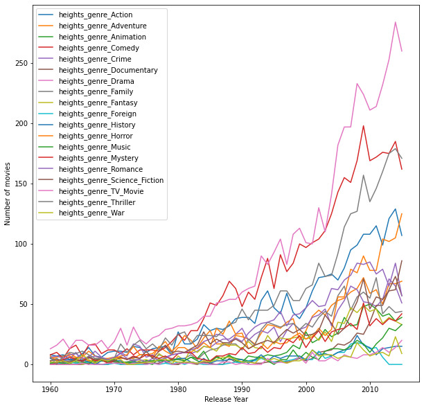

```python
#Now that we have all the data
#We want to show the information in a way we can get some insights
x = df_solution.groupby('release_year').sum()
locations = x.index[:].values

plt.figure(figsize=(10,10))

heights_genre_Action = x.iloc[:,0:1].iloc[:,:]
plt.plot(locations, heights_genre_Action, label="heights_genre_Action")

heights_genre_Adventure = x.iloc[:,1:2].iloc[:,:]
plt.plot(locations, heights_genre_Adventure, label="heights_genre_Adventure")

heights_genre_Animation = x.iloc[:,2:3].iloc[:,:]
plt.plot(locations, heights_genre_Animation, label="heights_genre_Animation")

heights_genre_Comedy = x.iloc[:,3:4].iloc[:,:]
plt.plot(locations, heights_genre_Comedy, label="heights_genre_Comedy")

heights_genre_Crime = x.iloc[:,4:5].iloc[:,:]
plt.plot(locations, heights_genre_Crime, label="heights_genre_Crime")

heights_genre_Documentary = x.iloc[:,5:6].iloc[:,:]
plt.plot(locations, heights_genre_Documentary, label="heights_genre_Documentary")

heights_genre_Drama = x.iloc[:,6:7].iloc[:,:]
plt.plot(locations, heights_genre_Drama, label="heights_genre_Drama")

heights_genre_Family = x.iloc[:,7:8].iloc[:,:]
plt.plot(locations, heights_genre_Family, label="heights_genre_Family")

heights_genre_Fantasy = x.iloc[:,8:9].iloc[:,:]
plt.plot(locations, heights_genre_Fantasy, label="heights_genre_Fantasy")

heights_genre_Foreign = x.iloc[:,9:10].iloc[:,:]
plt.plot(locations, heights_genre_Foreign, label="heights_genre_Foreign")

heights_genre_History = x.iloc[:,10:11].iloc[:,:]
plt.plot(locations, heights_genre_History, label="heights_genre_History")

heights_genre_Horror = x.iloc[:,11:12].iloc[:,:]
plt.plot(locations, heights_genre_Horror, label="heights_genre_Horror")

heights_genre_Music = x.iloc[:,12:13].iloc[:,:]
plt.plot(locations, heights_genre_Music, label="heights_genre_Music")

heights_genre_Mystery = x.iloc[:,13:14].iloc[:,:]
plt.plot(locations, heights_genre_Mystery, label="heights_genre_Mystery")

heights_genre_Romance = x.iloc[:,14:15].iloc[:,:]
plt.plot(locations, heights_genre_Romance, label="heights_genre_Romance")

heights_genre_Science_Fiction = x.iloc[:,15:16].iloc[:,:]
plt.plot(locations, heights_genre_Science_Fiction, label="heights_genre_Science_Fiction")

heights_genre_TV_Movie = x.iloc[:,16:17].iloc[:,:]
plt.plot(locations, heights_genre_TV_Movie, label="heights_genre_TV_Movie")

heights_genre_Thriller = x.iloc[:,17:18].iloc[:,:]
plt.plot(locations, heights_genre_Thriller, label="heights_genre_Thriller")

heights_genre_War = x.iloc[:,18:19].iloc[:,:]
plt.plot(locations, heights_genre_War, label="heights_genre_War")

plt.xlabel('Release Year')
plt.ylabel('Number of movies')
plt.legend()
plt.show
```

##### This line graph shows us that Drama, Comedy and Thriller are at the top most of the time year by year. At the bottom or among the less popular genres we have Foreign movies, TV Movie and War. In general there is a clear uptrend for most genres.

```python
#Peak values for each genre
#We can use these values to double check if last graph makes sense
x.max()
```

```
genre_Action             129
genre_Adventure           72
genre_Animation           50
genre_Comedy             198
genre_Crime               71
genre_Documentary         73
genre_Drama              284
genre_Family              72
genre_Fantasy             49
genre_Foreign             18
genre_History             24
genre_Horror             125
genre_Music               33
genre_Mystery             51
genre_Romance             85
genre_Science Fiction     86
genre_TV Movie            20
genre_Thriller           179
genre_War                 23
dtype: int64
```

### Research Question 2 What kind of properties are associated to high revenue movies?

#### 2.1: Do receive more revenue the most popular movies?

```python
#Function to draw bar plots. The argument is a column and it must be a number
def bar_plot(column = ""):
    median = df[column].median()
    low = df.query(column + ' < {}'.format(median))
    high = df.query(column + '>= {}'.format(median))
    mean_revenue_adj_low = low['revenue_adj'].mean()
    mean_revenue_adj_high = high['revenue_adj'].mean()
    #Create chart
    locations = [1, 2]
    heights = [mean_revenue_adj_low, mean_revenue_adj_high]
    labels = ['Low', 'High']
    plt.bar(locations, heights, tick_label=labels)
    plt.title('Average revenue_adj Ratings by {}'.format(column.title()))
    plt.xlabel(column.title())
    plt.ylabel('Average revenue_adj');
```

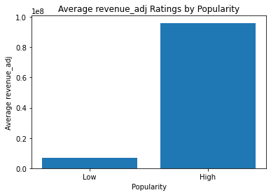

```python
bar_plot('popularity')
```

##### In this bar graph we can see that movies with popularity index above the median were able to achieve a higher revenue. Whilst on average the movies that had a popularity index lower than the median achieved less revenue in the time period of 1960 - 2015

#### 2.2: Do a movie receive more revenue the more runtime?

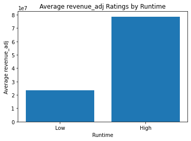

```python
bar_plot('runtime')
```

##### In this bar graph it can be seen that longer runtime movies achieved higher revenues.

##### Furthermore regarding runtime. What is the longest movie?

```python
df.query('runtime' + ' == {}'.format(df['runtime'].max()))['original_title']
```

```
3894    The Story of Film: An Odyssey
Name: original_title, dtype: object
```

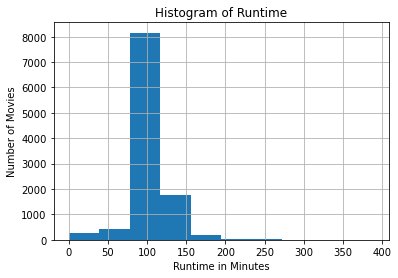

```python
#Single exploration of runtime using a histogram
df.query('runtime' + ' < {}'.format(400))['runtime'].hist()
plt.title('Histogram of Runtime')
plt.xlabel('Runtime in Minutes')
plt.ylabel('Number of Movies')
```

##### Most movies last only about 100 minutes. We can also say that the longest movie(The Story of Film: An Odyssey) which last 900 minutes is an oulier so that I only considered values less than 400.

#### 2.3: Do receive more revenue more vote_count movies?

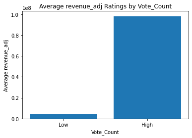

```python
bar_plot('vote_count')
```

##### Similarly to the last two bar graphs vote_count keeps a stright relationship with revenue. That is to a higher vote_count the movie achieved a higher revenue.

#### 2.4: Do receive more revenue the more budget of a movie?

```python
#We chose to separate in the 75% percentile because the 25% and 50% showed cero budget in average
mean_plus_75 = df.describe().iloc[:,8][6]
low = df.query('budget_adj < {}'.format(mean_plus_75))
high = df.query('budget_adj >= {}'.format(mean_plus_75))
mean_revenue_adj_low = low['revenue_adj'].mean()
mean_revenue_adj_high = high['revenue_adj'].mean()
```

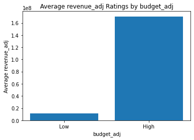

```python
# Create a bar chart of budget_adj vs revenue_adj
locations = [1, 2]
heights = [mean_revenue_adj_low, mean_revenue_adj_high]
labels = ['Low', 'High']
plt.bar(locations, heights, tick_label=labels)
plt.title('Average revenue_adj Ratings by budget_adj')
plt.xlabel('budget_adj')
plt.ylabel('Average revenue_adj');
```

##### The bar chart depicted average revenue_adj vs low and high budget_adj. It can be seen that to a higher budget_adj the movies achieved higher revenues_adj. To make this graph it was considered the 75% of the average value calulated with describe() method due to the fact that 25% and 50% percentile are zero.

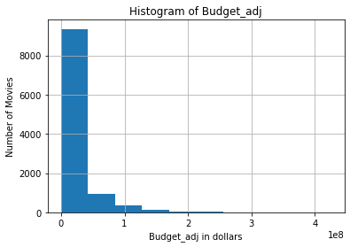

```python
#With a quick histogram we can see how most budget_adj are concentrated between 0 and 1 in a 1e8 scale
df['budget_adj'].hist()
plt.title('Histogram of Budget_adj')
plt.xlabel('Budget_adj in dollars')
plt.ylabel('Number of Movies')
```

##### We can see that many movies have nearly 0 budget which means missing as movies are not made for free

```python
#5710 movies have a budget less than 10 dollars
df[df.budget_adj < 10].shape
```

```
(5710, 41)
```

```python
#In order to fix this issue we are going to replace these values for an average
df.budget_adj.replace(0.000000e+00, df.budget_adj.mean(), inplace=True)
```

```python
#Now if we check the percentiles of budget_adj we see tgat 25% and 50% are not zero
df.describe()
```

|  | id | popularity | budget | revenue | runtime | vote_count | vote_average | release_year | budget_adj | revenue_adj |
| --- | --- | --- | --- | --- | --- | --- | --- | --- | --- | --- |
| count | 10866.000000 | 10866.000000 | 1.086600e+04 | 1.086600e+04 | 10866.000000 | 10866.000000 | 10866.000000 | 10866.000000 | 1.086600e+04 | 1.086600e+04 |
| mean | 66064.177434 | 0.646441 | 1.462570e+07 | 3.982332e+07 | 102.070863 | 217.389748 | 5.974922 | 2001.322658 | 2.675136e+07 | 5.136436e+07 |
| std | 92130.136561 | 1.000185 | 3.091321e+07 | 1.170035e+08 | 31.381405 | 575.619058 | 0.935142 | 12.812941 | 3.050850e+07 | 1.446325e+08 |
| min | 5.000000 | 0.000065 | 0.000000e+00 | 0.000000e+00 | 0.000000 | 10.000000 | 1.500000 | 1960.000000 | 9.210911e-01 | 0.000000e+00 |
| 25% | 10596.250000 | 0.207583 | 0.000000e+00 | 0.000000e+00 | 90.000000 | 17.000000 | 5.400000 | 1995.000000 | 1.755104e+07 | 0.000000e+00 |
| 50% | 20669.000000 | 0.383856 | 0.000000e+00 | 0.000000e+00 | 99.000000 | 38.000000 | 6.000000 | 2006.000000 | 1.755104e+07 | 0.000000e+00 |
| 75% | 75610.000000 | 0.713817 | 1.500000e+07 | 2.400000e+07 | 111.000000 | 145.750000 | 6.600000 | 2011.000000 | 2.085325e+07 | 3.369710e+07 |
| max | 417859.000000 | 32.985763 | 4.250000e+08 | 2.781506e+09 | 900.000000 | 9767.000000 | 9.200000 | 2015.000000 | 4.250000e+08 | 2.827124e+09 |

```python
#Function to draw bar plots percentiles from describe method
def bar_plot_percentiles(column = ""):
    below_25 = df.query(column + '< {}'.format(df.describe().iloc[:,df.describe().columns.get_loc(column)][4]))
    between_25_50 = df.query(column + ' >= {} & vote_average < {}'.format(df.describe().iloc[:,df.describe().columns.get_loc(column)][4], df.describe().iloc[:,df.describe().columns.get_loc(column)][5]))
    between_50_75 = df.query(column + ' >= {} & vote_average < {}'.format(df.describe().iloc[:,df.describe().columns.get_loc(column)][5], df.describe().iloc[:,df.describe().columns.get_loc(column)][6]))
    plus_75 = df.query(column + ' >= {}'.format(df.describe().iloc[:,df.describe().columns.get_loc(column)][6]))

    mean_below_25 = below_25['revenue_adj'].mean()
    mean_between_25_50 = between_25_50['revenue_adj'].mean()
    mean_between_50_75 = between_50_75['revenue_adj'].mean()
    mean_plus_75 = plus_75['revenue_adj'].mean()

    # Create a bar chart of 'columns' vs average revenue_adj
    locations = [1, 2, 3, 4]
    heights = [mean_below_25, mean_between_25_50, mean_between_50_75, mean_plus_75]
    labels = ['Low', 'Upper Low', 'High', 'Upper High']
    plt.bar(locations, heights, tick_label=labels)
    plt.title('Average revenue_adj Ratings by {}'.format(column.title()))
    plt.xlabel(column.title())
    plt.ylabel('Average revenue_adj');
```

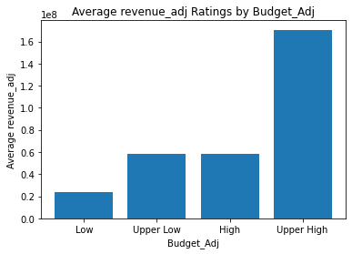

```python
#We make use of the above function to draw budget_adj
bar_plot_percentiles('budget_adj')
```

##### The graph shows values for the lower percentiles as we filled them with average values of the whole column. There is no variation in the middle percentiles as they have the same values from the describe method.

#### 2.5: Do receive more revenue more vote_average movies?

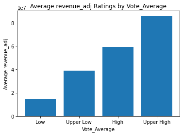

```python
#Now again we use the function to draw the percentiles
bar_plot_percentiles('vote_average')
```

##### In this bar graph based on the describe method percentiles we can see an up trend the more vote_average we get the more revenue_adj the movie achieve.

## Conclusions

> **Question 1**: We clearly saw that the most popular genre during the period of 1960-2015 was Drama followed by Comedy. Drama was above all most of the time except during a small period in the lat eighties when Comedy took the lead. In the other side we can see that Foreign movies, TV Movie and War did not account much and were mostly at the bottom of the line chart.

> **Question 2**: We wanted to know what properties related to high revenue movies. We chose to use the filed revenue_adj which the revenue adjusted by inflation at 2010. This seemed a fairer parameter because there are movies from other decades and their value is depreciated with time. Some of the parameters we looked at are popularity, runtime, vote_count, budget_adj and vote_average. In the firt exercise we separated popularity in two groups low and high popular movies. Finding out that highly popular movies tend to achive a high revenue_adj as well. Similarly, for runtime, budget_adj and vote_count we found that to a higher runtime, budget_adj and vote_count we achieved higher revenue. We also analysed filling budget_adj zero values with the average of the column and four percentiles from describe method. We achieved similar results seeing that the more budget_adj we get more revenue_adj. In the last excercise we divided vote_average in four categories to see if there was a variation. However, it was similar and showed that to a higher vote_average there was higher revenue_adj. Some limitation of the study is that I only analysed five factors regarding the revenue of movies and there might others properties we left out that correlate or affect the revenue as well.